# Implementation of CNN

Data Mining

## using *CIFAR10* dataset

```r
# Load Libraries
library(keras)
library(dplyr)
library(tidyr)
library(stringr)
library(ggplot2)
library(imager)
```

### Load Dataset

```r
# Load CIFAR10 DataSet
cifar <- dataset_cifar10()
c(Xtrain, Ytrain) %<-% cifar$train
c(Xtest, Ytest) %<-% cifar$test

n_class <- 10
img_size <- 32

cat('Dim of Images in Training + Validation Set:', dim(Xtrain), '\n')
```

```
## Dim of Images in Training + Validation Set: 50000 32 32 3
```

```r
cat('Dim of Images in Test Set:', dim(Xtest), '\n')
```

```
## Dim of Images in Test Set: 10000 32 32 3
```

```r
cat('\n')
```

```r
cat('Number of Labels per class in Training + Validation Set:', '\n')
```

```
## Number of Labels per class in Training + Validation Set:
```

```r
print(table(class = Ytrain))
```

```
## class
##    0    1    2    3    4    5    6    7    8    9
## 5000 5000 5000 5000 5000 5000 5000 5000 5000 5000
```

```r
cat('\n')
```

```r
cat('Number of Labels per class in Test Set:', '\n')
```

```
## Number of Labels per class in Test Set:
```

```r
print(table(class = Ytest))
```

```
## class
##    0    1    2    3    4    5    6    7    8    9
## 1000 1000 1000 1000 1000 1000 1000 1000 1000 1000
```

#### 10 Class Labels

```r
classInfo <- data.frame(
  Index = 0:9,
  Label = c('airplane', 'automobile', 'bird', 'cat', 'deer',
            'dog', 'frog', 'horse', 'ship', 'truck')
)
classInfo
```

| Index | Label |
| --- | --- |
| 0 | airplane |
| 1 | automobile |
| 2 | bird |
| 3 | cat |
| 4 | deer |
| 5 | dog |
| 6 | frog |
| 7 | horse |
| 8 | ship |
| 9 | truck |

#### Test Sample Images for each class

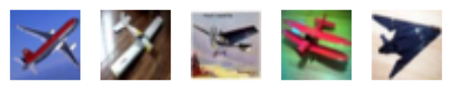

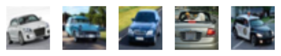

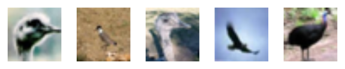

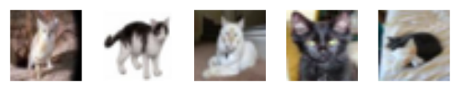

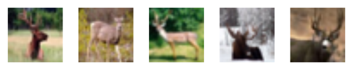

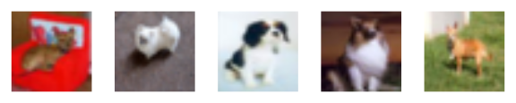

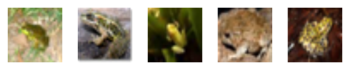

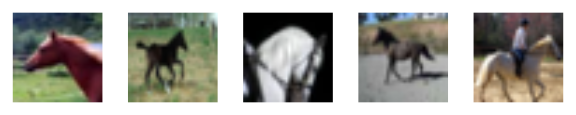

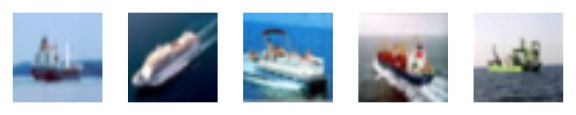

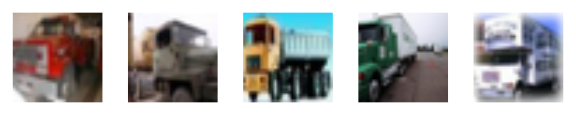

```r
# Quick function for drawing
draw.image <- function(index) {
  img <- Xtest[index,,,]
  r <- img[,,1] ; g <- img[,,2] ; b <- img[,,3]
  img.array <- array(dim = c(img_size, img_size, 1, 3))
  img.array[,,1,1] <- t(r)
  img.array[,,1,2] <- t(g)
  img.array[,,1,3] <- t(b)

  plot(cimg(img.array), axes = FALSE)
}

for (class in 1:n_class) {
  id <- sample(which(Ytest == class -1), 5)
  par(mfrow = c(1, 5), mar = c(1, 1, 1, 1))
  for (idi in id) draw.image(idi)
}
```

### Data Transformation

```r
# Transform RGB values into [0, 1] range
Xtrain <- Xtrain / 255
Xtest <- Xtest / 255

# Apply One-Hot Encoding
Ytrain <- Ytrain %>% to_categorical(n_class)
Ytest <- Ytest %>% to_categorical(n_class)
```

### Data Split

#### Training and Validation Set

50,000개의 훈련 이미지를 다시 40,000개(80%)의 훈련용 이미지와 10,000개(20%)의 검증용 이미지로 분리한다.

```r
set.seed(100)
val <- sample(nrow(Xtrain), nrow(Xtrain)*0.2)
Xval <- Xtrain[val,,,]
Yval <- Ytrain[val,]
Xtrain <- Xtrain[-val,,,]
Ytrain <- Ytrain[-val,]
```

## **Training**

### Overall Structure

- Contain 3 Blocks of **Convolution-Pooling** Layers

| Layer | Number of Output Channels | Filter Size |
| --- | --- | --- |
| Input | 3 | - |
| Convolution 1 | 16 | (3, 3) |
| Convolution 2 | 32 | (3, 3) |
| Convolution 3 | 64 | (3, 3) |
| Dense | 128 | - |
| Output | 10 | - |

- Functions for Result Shortcuts

```r
# History Plot for Loss & Accuracy
history.plot <- function(history, method = 'val_acc') {
  if (is.data.frame(history)) { gtb <- history }
  else { gtb <- as.data.frame(history$metrics) }
  minim <- ifelse(method == 'val_loss', which.min(gtb$val_loss), which.max(gtb$val_acc))
  epoch <- 1:nrow(gtb)
  g <- ggplot(gtb) + theme_test() +
    theme(plot.title = element_text(hjust = 0.5), legend.position = 'bottom') +
    scale_color_manual('set', values = c(training = 'darkblue', validation = 'red1'))
  g1 <- g +
    geom_vline(aes(xintercept = minim), color = 'gray', linetype = 2) +
    geom_line(aes(epoch, loss, color = 'training')) +
    geom_line(aes(epoch, val_loss, color = 'validation')) +
    labs(title = 'Loss')
  g2 <- g +
    geom_vline(aes(xintercept = minim), color = 'gray', linetype = 2) +
    geom_line(aes(epoch, acc, color = 'training')) +
    geom_line(aes(epoch, val_acc, color = 'validation')) +
    labs(title = 'Accuracy')
  gridExtra::grid.arrange(g1, g2, ncol = 2)
}

# Evaluation Table for Each Sample Set
evaluate.table <- function(model) {
  result_train <- model %>% evaluate(Xtrain, Ytrain, verbose = 2) %>% unlist
  result_val <- model %>% evaluate(Xval, Yval, verbose = 2) %>% unlist
  result_te <- model %>% evaluate(Xtest, Ytest, verbose = 2) %>% unlist
  as.data.frame(rbind(
    train = result_train, validation = result_val, test = result_te
  ))
}
```

### 1. Basic Model

- 1 Convolution Layer per block

```r
# Define
model1 <- keras_model_sequential() %>%
  layer_conv_2d(input_shape = c(img_size, img_size, 3),
                16, c(3, 3), activation = 'relu', padding = 'same',
                kernel_initializer = 'he_uniform',
                name = '1_conv') %>%
  layer_max_pooling_2d(c(2, 2), padding = 'same', name = '1_pool') %>%
  layer_conv_2d(32, c(3, 3), activation = 'relu', padding = 'same',
                kernel_initializer = 'he_uniform',
                name = '2_conv') %>%
  layer_max_pooling_2d(c(2, 2), padding = 'same', name = '2_pool') %>%
  layer_conv_2d(64, c(3, 3), activation = 'relu', padding = 'same',
                kernel_initializer = 'he_uniform',
                name = '3_conv') %>%
  layer_max_pooling_2d(c(2, 2), padding = 'same', name = '3_pool') %>%
  layer_flatten(name = 'flatten') %>%
  layer_dense(n_class, activation = 'softmax', name = 'output')

# Compile
model1 %>% compile(
  loss = 'categorical_crossentropy',
  metrics = 'accuracy',
  optimizer = optimizer_rmsprop(lr = 1e-3, decay = 1e-6)
)
```

학습률(learning rate)은 0.001으로 시작해 업데이트가 한 번 이루어질 때마다 1e-6씩 감소(decay)하도록 설정한다.

```r
model1
```

```
## Model
## ___________________________________________________________________________
## Layer (type)                     Output Shape                  Param #
## ===========================================================================
## 1_conv (Conv2D)                  (None, 32, 32, 16)            448
## ___________________________________________________________________________
## 1_pool (MaxPooling2D)            (None, 16, 16, 16)            0
## ___________________________________________________________________________
## 2_conv (Conv2D)                  (None, 16, 16, 32)            4640
## ___________________________________________________________________________
## 2_pool (MaxPooling2D)            (None, 8, 8, 32)              0
## ___________________________________________________________________________
## 3_conv (Conv2D)                  (None, 8, 8, 64)              18496
## ___________________________________________________________________________
## 3_pool (MaxPooling2D)            (None, 4, 4, 64)              0
## ___________________________________________________________________________
## flatten (Flatten)                (None, 1024)                  0
## ___________________________________________________________________________
## output (Dense)                   (None, 10)                    10250
## ===========================================================================
## Total params: 33,834
## Trainable params: 33,834
## Non-trainable params: 0
## ___________________________________________________________________________
```

#### *Callbacks*

- *model_checkpoint*(save_best_only=TRUE): 지정한 디렉토리 경로에 monitor를 기준으로 최적의 모형을 저장한다.
- *early_stopping*: monitor로 설정한 측정치가 지정한 patience 이상의 epoch 동안 향상되지 않을 경우 학습을 조기 종료한다.

```r
modelpath <- 'Model/model-user-he-1.hdf5'
saving <- callback_model_checkpoint(modelpath, monitor = 'val_acc', save_best_only = TRUE)
stopping <- callback_early_stopping(monitor = 'val_acc', patience = 20)
```

```r
epochs <- 100
batch_size <- 32

# Start Training
history1 <- model1 %>% fit(
  Xtrain, Ytrain, validation_data = list(Xval, Yval),
  epochs = epochs, batch_size = batch_size,
  callbacks = list(saving, stopping), verbose = 2
)

# Save History to a CSV file
write.csv(as.data.frame(history1$metrics), 'Model/history-user-he-1.csv', row.names = FALSE)
```

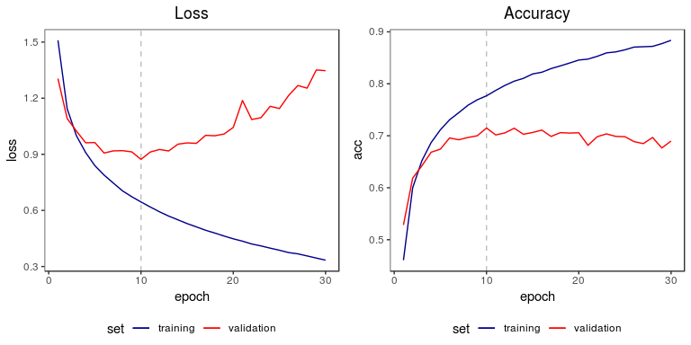

```r
history.plot(history1)
```

#### Model Evaluation

```r
model1 <- load_model_hdf5(modelpath)
```

checkpoint로 지정한 경로에 저장된 최적 모형을 다시 불러와 모형 평가에 사용한다.

```r
result1 <- evaluate.table(model1)
result1
```

|  | loss | acc |
| --- | --- | --- |
| train | 0.5408589 | 0.81755 |
| validation | 0.8727526 | 0.71490 |
| test | 0.8683392 | 0.71040 |

## Deeper Models

### 2. Model 2

- Stack 2 Convolution layers per block

```r
# Define
(model2 <- keras_model_sequential() %>%
  layer_conv_2d(input_shape = c(img_size, img_size, 3),
                16, c(3, 3), activation = 'relu', padding = 'same',
                kernel_initializer = 'he_uniform', name = '1_conv1') %>%
  layer_conv_2d(16, c(3, 3), activation = 'relu', padding = 'same',
                kernel_initializer = 'he_uniform', name = '1_conv2') %>%
  layer_max_pooling_2d(c(2, 2), padding = 'same', name = '1_pool') %>%
  layer_conv_2d(32, c(3, 3), activation = 'relu', padding = 'same',
                kernel_initializer = 'he_uniform', name = '2_conv1') %>%
  layer_conv_2d(32, c(3, 3), activation = 'relu', padding = 'same',
                kernel_initializer = 'he_uniform', name = '2_conv2') %>%
  layer_max_pooling_2d(c(2, 2), padding = 'same', name = '2_pool') %>%
  layer_conv_2d(64, c(3, 3), activation = 'relu', padding = 'same',
                kernel_initializer = 'he_uniform', name = '3_conv1') %>%
  layer_conv_2d(64, c(3, 3), activation = 'relu', padding = 'same',
                kernel_initializer = 'he_uniform', name = '3_conv2') %>%
  layer_max_pooling_2d(c(2, 2), padding = 'same', name = '3_pool') %>%
  layer_flatten(name = 'flatten') %>%
  layer_dense(n_class, activation = 'softmax', name = 'output'))
```

```
## Model
## ___________________________________________________________________________
## Layer (type)                     Output Shape                  Param #
## ===========================================================================
## 1_conv1 (Conv2D)                 (None, 32, 32, 16)            448
## ___________________________________________________________________________
## 1_conv2 (Conv2D)                 (None, 32, 32, 16)            2320
## ___________________________________________________________________________
## 1_pool (MaxPooling2D)            (None, 16, 16, 16)            0
## ___________________________________________________________________________
## 2_conv1 (Conv2D)                 (None, 16, 16, 32)            4640
## ___________________________________________________________________________
## 2_conv2 (Conv2D)                 (None, 16, 16, 32)            9248
## ___________________________________________________________________________
## 2_pool (MaxPooling2D)            (None, 8, 8, 32)              0
## ___________________________________________________________________________
## 3_conv1 (Conv2D)                 (None, 8, 8, 64)              18496
## ___________________________________________________________________________
## 3_conv2 (Conv2D)                 (None, 8, 8, 64)              36928
## ___________________________________________________________________________
## 3_pool (MaxPooling2D)            (None, 4, 4, 64)              0
## ___________________________________________________________________________
## flatten (Flatten)                (None, 1024)                  0
## ___________________________________________________________________________
## output (Dense)                   (None, 10)                    10250
## ===========================================================================
## Total params: 82,330
## Trainable params: 82,330
## Non-trainable params: 0
## ___________________________________________________________________________
```

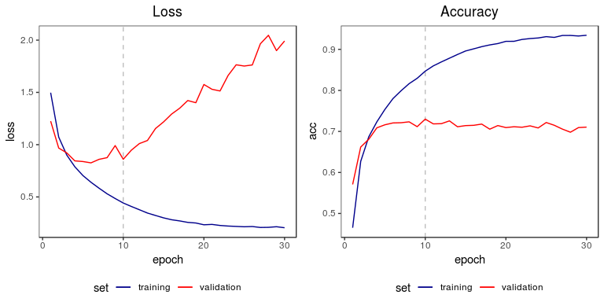

```r
# Result 1
history.plot(history2)
```

```r
# Result 2
model2 <- load_model_hdf5('Model/model-user-he-2.hdf5')
result2 <- evaluate.table(model2)
result2
```

|  | loss | acc |
| --- | --- | --- |
| train | 0.3227826 | 0.8921 |
| validation | 0.8601935 | 0.7300 |
| test | 0.9005035 | 0.7266 |

### 3. Model 2 + BN

- Stack 2 Convolution Layers per block
- Add **Batch Normalization** steps before each activation in Convolution Layers

```r
# Define
(model2_bn <- keras_model_sequential() %>%

  layer_conv_2d(input_shape = c(img_size, img_size, 3),
                16, c(3, 3), padding = 'same',
                kernel_initializer = 'he_uniform', name = '1_conv1') %>%
  layer_batch_normalization(name = '1_bn1') %>%
  layer_activation_relu(name = '1_activation1') %>%
  layer_conv_2d(16, c(3, 3), padding = 'same',
                kernel_initializer = 'he_uniform', name = '1_conv2') %>%
  layer_batch_normalization(name = '1_bn2') %>%
  layer_activation_relu(name = '1_activation2') %>%
  layer_max_pooling_2d(c(2, 2), padding = 'same', name = '1_pool') %>%

  layer_conv_2d(32, c(3, 3), padding = 'same',
                kernel_initializer = 'he_uniform', name = '2_conv1') %>%
  layer_batch_normalization(name = '2_bn1') %>%
  layer_activation_relu(name = '2_activation1') %>%
  layer_conv_2d(32, c(3, 3), padding = 'same',
                kernel_initializer = 'he_uniform', name = '2_conv2') %>%
  layer_batch_normalization(name = '2_bn2') %>%
  layer_activation_relu(name = '2_activation2') %>%
  layer_max_pooling_2d(c(2, 2), padding = 'same', name = '2_pool') %>%

  layer_conv_2d(64, c(3, 3), padding = 'same',
                kernel_initializer = 'he_uniform', name = '3_conv1') %>%
  layer_batch_normalization(name = '3_bn1') %>%
  layer_activation_relu(name = '3_activation1') %>%
  layer_conv_2d(64, c(3, 3), padding = 'same',
                kernel_initializer = 'he_uniform', name = '3_conv2') %>%
  layer_batch_normalization(name = '3_bn2') %>%
  layer_activation_relu(name = '3_activation2') %>%
  layer_max_pooling_2d(c(2, 2), padding = 'same', name = '3_pool') %>%

  layer_flatten(name = 'flatten') %>%
  layer_dense(n_class, activation = 'softmax', name = 'output'))
```

```
## Model
## ___________________________________________________________________________
## Layer (type)                     Output Shape                  Param #
## ===========================================================================
## 1_conv1 (Conv2D)                 (None, 32, 32, 16)            448
## ___________________________________________________________________________
## 1_bn1 (BatchNormalization)       (None, 32, 32, 16)            64
## ___________________________________________________________________________
## 1_activation1 (ReLU)             (None, 32, 32, 16)            0
## ___________________________________________________________________________
## 1_conv2 (Conv2D)                 (None, 32, 32, 16)            2320
## ___________________________________________________________________________
## 1_bn2 (BatchNormalization)       (None, 32, 32, 16)            64
## ___________________________________________________________________________
## 1_activation2 (ReLU)             (None, 32, 32, 16)            0
## ___________________________________________________________________________
## 1_pool (MaxPooling2D)            (None, 16, 16, 16)            0
## ___________________________________________________________________________
## 2_conv1 (Conv2D)                 (None, 16, 16, 32)            4640
## ___________________________________________________________________________
## 2_bn1 (BatchNormalization)       (None, 16, 16, 32)            128
## ___________________________________________________________________________
## 2_activation1 (ReLU)             (None, 16, 16, 32)            0
## ___________________________________________________________________________
## 2_conv2 (Conv2D)                 (None, 16, 16, 32)            9248
## ___________________________________________________________________________
## 2_bn2 (BatchNormalization)       (None, 16, 16, 32)            128
## ___________________________________________________________________________
## 2_activation2 (ReLU)             (None, 16, 16, 32)            0
## ___________________________________________________________________________
## 2_pool (MaxPooling2D)            (None, 8, 8, 32)              0
## ___________________________________________________________________________
## 3_conv1 (Conv2D)                 (None, 8, 8, 64)              18496
## ___________________________________________________________________________
## 3_bn1 (BatchNormalization)       (None, 8, 8, 64)              256
## ___________________________________________________________________________
## 3_activation1 (ReLU)             (None, 8, 8, 64)              0
## ___________________________________________________________________________
## 3_conv2 (Conv2D)                 (None, 8, 8, 64)              36928
## ___________________________________________________________________________
## 3_bn2 (BatchNormalization)       (None, 8, 8, 64)              256
## ___________________________________________________________________________
## 3_activation2 (ReLU)             (None, 8, 8, 64)              0
## ___________________________________________________________________________
## 3_pool (MaxPooling2D)            (None, 4, 4, 64)              0
## ___________________________________________________________________________
## flatten (Flatten)                (None, 1024)                  0
## ___________________________________________________________________________
## output (Dense)                   (None, 10)                    10250
## ===========================================================================
## Total params: 83,226
## Trainable params: 82,778
## Non-trainable params: 448
## ___________________________________________________________________________
```

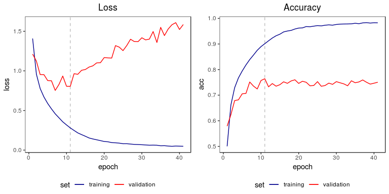

```r
# Result 1
history.plot(history2_bn)
```

```r
# Result 2
model2_bn <- load_model_hdf5('Model/model-user-he-2-bn.hdf5')
result2_bn <- evaluate.table(model2_bn)
result2_bn
```

|  | loss | acc |
| --- | --- | --- |
| train | 0.2164634 | 0.92575 |
| validation | 0.8049686 | 0.76420 |
| test | 0.8454445 | 0.76110 |

### 4. Model 2 + BN + FC (+ DO) 1

- Stack 2 Convolution Layers per block
- Add Batch Normalization step before each activation in Convolution Layers
- Add 1 Fully-Connected Layer + Dropout (0.1) Layer before the final output layer

```r
# Define
(model2_bn_fc1 <- keras_model_sequential() %>%

  layer_conv_2d(input_shape = c(img_size, img_size, 3),
                16, c(3, 3), padding = 'same',
                kernel_initializer = 'he_uniform', name = '1_conv1') %>%
  layer_batch_normalization(name = '1_bn1') %>%
  layer_activation_relu(name = '1_activation1') %>%
  layer_conv_2d(16, c(3, 3), padding = 'same',
                kernel_initializer = 'he_uniform', name = '1_conv2') %>%
  layer_batch_normalization(name = '1_bn2') %>%
  layer_activation_relu(name = '1_activation2') %>%
  layer_max_pooling_2d(c(2, 2), name = '1_pool') %>%

  layer_conv_2d(32, c(3, 3), padding = 'same',
                kernel_initializer = 'he_uniform', name = '2_conv1') %>%
  layer_batch_normalization(name = '2_bn1') %>%
  layer_activation_relu(name = '2_activation1') %>%
  layer_conv_2d(32, c(3, 3), padding = 'same',
                kernel_initializer = 'he_uniform', name = '2_conv2') %>%
  layer_batch_normalization(name = '2_bn2') %>%
  layer_activation_relu(name = '2_activation2') %>%
  layer_max_pooling_2d(c(2, 2), name = '2_pool') %>%

  layer_conv_2d(64, c(3, 3), padding = 'same',
                kernel_initializer = 'he_uniform', name = '3_conv1') %>%
  layer_batch_normalization(name = '3_bn1') %>%
  layer_activation_relu(name = '3_activation1') %>%
  layer_conv_2d(64, c(3, 3), padding = 'same',
                kernel_initializer = 'he_uniform', name = '3_conv2') %>%
  layer_batch_normalization(name = '3_bn2') %>%
  layer_activation_relu(name = '3_activation2') %>%
  layer_max_pooling_2d(c(2, 2), name = '3_pool') %>%

  layer_flatten(name = 'flatten') %>%

  layer_dense(128, activation = 'relu', kernel_initializer = 'he_uniform', name = '1_dense') %>%
  layer_dropout(0.1, name = '1_dropout') %>%

  layer_dense(n_class, activation = 'softmax', name = 'output'))
```

```
## Model
## ___________________________________________________________________________
## Layer (type)                     Output Shape                  Param #
## ===========================================================================
## 1_conv1 (Conv2D)                 (None, 32, 32, 16)            448
## ___________________________________________________________________________
## 1_bn1 (BatchNormalization)       (None, 32, 32, 16)            64
## ___________________________________________________________________________
## 1_activation1 (ReLU)             (None, 32, 32, 16)            0
## ___________________________________________________________________________
## 1_conv2 (Conv2D)                 (None, 32, 32, 16)            2320
## ___________________________________________________________________________
## 1_bn2 (BatchNormalization)       (None, 32, 32, 16)            64
## ___________________________________________________________________________
## 1_activation2 (ReLU)             (None, 32, 32, 16)            0
## ___________________________________________________________________________
## 1_pool (MaxPooling2D)            (None, 16, 16, 16)            0
## ___________________________________________________________________________
## 2_conv1 (Conv2D)                 (None, 16, 16, 32)            4640
## ___________________________________________________________________________
## 2_bn1 (BatchNormalization)       (None, 16, 16, 32)            128
## ___________________________________________________________________________
## 2_activation1 (ReLU)             (None, 16, 16, 32)            0
## ___________________________________________________________________________
## 2_conv2 (Conv2D)                 (None, 16, 16, 32)            9248
## ___________________________________________________________________________
## 2_bn2 (BatchNormalization)       (None, 16, 16, 32)            128
## ___________________________________________________________________________
## 2_activation2 (ReLU)             (None, 16, 16, 32)            0
## ___________________________________________________________________________
## 2_pool (MaxPooling2D)            (None, 8, 8, 32)              0
## ___________________________________________________________________________
## 3_conv1 (Conv2D)                 (None, 8, 8, 64)              18496
## ___________________________________________________________________________
## 3_bn1 (BatchNormalization)       (None, 8, 8, 64)              256
## ___________________________________________________________________________
## 3_activation1 (ReLU)             (None, 8, 8, 64)              0
## ___________________________________________________________________________
## 3_conv2 (Conv2D)                 (None, 8, 8, 64)              36928
## ___________________________________________________________________________
## 3_bn2 (BatchNormalization)       (None, 8, 8, 64)              256
## ___________________________________________________________________________
## 3_activation2 (ReLU)             (None, 8, 8, 64)              0
## ___________________________________________________________________________
## 3_pool (MaxPooling2D)            (None, 4, 4, 64)              0
## ___________________________________________________________________________
## flatten (Flatten)                (None, 1024)                  0
## ___________________________________________________________________________
## 1_dense (Dense)                  (None, 128)                   131200
## ___________________________________________________________________________
## 1_dropout (Dropout)              (None, 128)                   0
## ___________________________________________________________________________
## output (Dense)                   (None, 10)                    1290
## ===========================================================================
## Total params: 205,466
## Trainable params: 205,018
## Non-trainable params: 448
## ___________________________________________________________________________
```

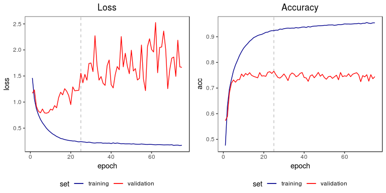

```r
# Result 1
history.plot(history2_bn_fc1)
```

```r
# Result 2
model2_bn_fc1 <- load_model_hdf5('Model/model-user-2-bn-fc-do-1.hdf5')
result2_bn_fc1 <- evaluate.table(model2_bn_fc1)
result2_bn_fc1
```

|  | loss | acc |
| --- | --- | --- |
| train | 0.2044178 | 0.9394 |
| validation | 1.5533505 | 0.7658 |
| test | 1.5894560 | 0.7635 |

### 5. Model 2 + BN + FC (+ DO) 2

- Stack 2 Convolution Layers per block
- Add Batch Normalization step before each activation in Convolution Layers
- Add 2 Fully-Connected Layers + Dropout (0.1) Layers before the final output layer

```r
(model2_bn_fc2 <- keras_model_sequential() %>%

  layer_conv_2d(input_shape = c(img_size, img_size, 3),
                16, c(3, 3), padding = 'same',
                kernel_initializer = 'he_uniform', name = '1_conv1') %>%
  layer_batch_normalization(name = '1_bn1') %>%
  layer_activation_relu(name = '1_activation1') %>%
  layer_conv_2d(16, c(3, 3), padding = 'same',
                kernel_initializer = 'he_uniform', name = '1_conv2') %>%
  layer_batch_normalization(name = '1_bn2') %>%
  layer_activation_relu(name = '1_activation2') %>%
  layer_max_pooling_2d(c(2, 2), name = '1_pool') %>%

  layer_conv_2d(32, c(3, 3), padding = 'same',
                kernel_initializer = 'he_uniform', name = '2_conv1') %>%
  layer_batch_normalization(name = '2_bn1') %>%
  layer_activation_relu(name = '2_activation1') %>%
  layer_conv_2d(32, c(3, 3), padding = 'same',
                kernel_initializer = 'he_uniform', name = '2_conv2') %>%
  layer_batch_normalization(name = '2_bn2') %>%
  layer_activation_relu(name = '2_activation2') %>%
  layer_max_pooling_2d(c(2, 2), name = '2_pool') %>%

  layer_conv_2d(64, c(3, 3), padding = 'same',
                kernel_initializer = 'he_uniform', name = '3_conv1') %>%
  layer_batch_normalization(name = '3_bn1') %>%
  layer_activation_relu(name = '3_activation1') %>%
  layer_conv_2d(64, c(3, 3), padding = 'same',
                kernel_initializer = 'he_uniform', name = '3_conv2') %>%
  layer_batch_normalization(name = '3_bn2') %>%
  layer_activation_relu(name = '3_activation2') %>%
  layer_max_pooling_2d(c(2, 2), name = '3_pool') %>%

  layer_flatten(name = 'flatten') %>%

  layer_dense(128, activation = 'relu',
              kernel_initializer = 'he_uniform', name = '1_dense') %>%
  layer_dropout(0.1, name = '1_dropout') %>%

  layer_dense(128, activation = 'relu',
              kernel_initializer = 'he_uniform', name = '2_dense') %>%
  layer_dropout(0.1, name = '2_dropout') %>%

  layer_dense(n_class, activation = 'softmax', name = 'output'))
```

```
## Model
## ___________________________________________________________________________
## Layer (type)                     Output Shape                  Param #
## ===========================================================================
## 1_conv1 (Conv2D)                 (None, 32, 32, 16)            448
## ___________________________________________________________________________
## 1_bn1 (BatchNormalization)       (None, 32, 32, 16)            64
## ___________________________________________________________________________
## 1_activation1 (ReLU)             (None, 32, 32, 16)            0
## ___________________________________________________________________________
## 1_conv2 (Conv2D)                 (None, 32, 32, 16)            2320
## ___________________________________________________________________________
## 1_bn2 (BatchNormalization)       (None, 32, 32, 16)            64
## ___________________________________________________________________________
## 1_activation2 (ReLU)             (None, 32, 32, 16)            0
## ___________________________________________________________________________
## 1_pool (MaxPooling2D)            (None, 16, 16, 16)            0
## ___________________________________________________________________________
## 2_conv1 (Conv2D)                 (None, 16, 16, 32)            4640
## ___________________________________________________________________________
## 2_bn1 (BatchNormalization)       (None, 16, 16, 32)            128
## ___________________________________________________________________________
## 2_activation1 (ReLU)             (None, 16, 16, 32)            0
## ___________________________________________________________________________
## 2_conv2 (Conv2D)                 (None, 16, 16, 32)            9248
## ___________________________________________________________________________
## 2_bn2 (BatchNormalization)       (None, 16, 16, 32)            128
## ___________________________________________________________________________
## 2_activation2 (ReLU)             (None, 16, 16, 32)            0
## ___________________________________________________________________________
## 2_pool (MaxPooling2D)            (None, 8, 8, 32)              0
## ___________________________________________________________________________
## 3_conv1 (Conv2D)                 (None, 8, 8, 64)              18496
## ___________________________________________________________________________
## 3_bn1 (BatchNormalization)       (None, 8, 8, 64)              256
## ___________________________________________________________________________
## 3_activation1 (ReLU)             (None, 8, 8, 64)              0
## ___________________________________________________________________________
## 3_conv2 (Conv2D)                 (None, 8, 8, 64)              36928
## ___________________________________________________________________________
## 3_bn2 (BatchNormalization)       (None, 8, 8, 64)              256
## ___________________________________________________________________________
## 3_activation2 (ReLU)             (None, 8, 8, 64)              0
## ___________________________________________________________________________
## 3_pool (MaxPooling2D)            (None, 4, 4, 64)              0
## ___________________________________________________________________________
## flatten (Flatten)                (None, 1024)                  0
## ___________________________________________________________________________
## 1_dense (Dense)                  (None, 128)                   131200
## ___________________________________________________________________________
## 1_dropout (Dropout)              (None, 128)                   0
## ___________________________________________________________________________
## 2_dense (Dense)                  (None, 128)                   16512
## ___________________________________________________________________________
## 2_dropout (Dropout)              (None, 128)                   0
## ___________________________________________________________________________
## output (Dense)                   (None, 10)                    1290
## ===========================================================================
## Total params: 221,978
## Trainable params: 221,530
## Non-trainable params: 448
## ___________________________________________________________________________
```

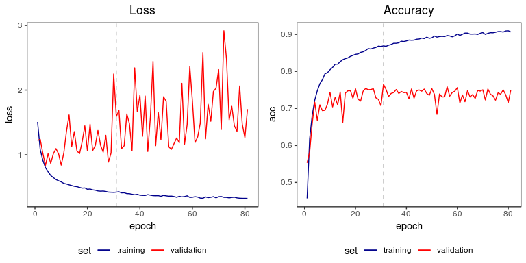

```r
# Result 1
history.plot(history2_bn_fc2)
```

```r
# Result 2
model2_bn_fc2 <- load_model_hdf5('Model/model-user-2-bn-fc-do-2.hdf5')
result2_bn_fc2 <- evaluate.table(model2_bn_fc2)
result2_bn_fc2
```

|  | loss | acc |
| --- | --- | --- |
| train | 0.4455112 | 0.8962 |
| validation | 1.5909533 | 0.7653 |
| test | 1.6671518 | 0.7581 |

### 6. Model 3 + BN

- Stack 3 Convolution Layers per block
- Add Batch Normalization step before each activation in Convolution Layers

```r
# Define
(model3_bn <- keras_model_sequential() %>%

  layer_conv_2d(input_shape = c(img_size, img_size, 3),
                16, c(3, 3), padding = 'same',
                kernel_initializer = 'he_uniform', name = '1_conv1') %>%
  layer_batch_normalization(name = '1_bn1') %>%
  layer_activation_relu(name = '1_activation1') %>%
  layer_conv_2d(16, c(3, 3), padding = 'same',
                kernel_initializer = 'he_uniform', name = '1_conv2') %>%
  layer_batch_normalization(name = '1_bn2') %>%
  layer_activation_relu(name = '1_activation2') %>%
  layer_conv_2d(16, c(3, 3), padding = 'same',
                kernel_initializer = 'he_uniform', name = '1_conv3') %>%
  layer_batch_normalization(name = '1_bn3') %>%
  layer_activation_relu(name = '1_activation3') %>%
  layer_max_pooling_2d(c(2, 2), padding = 'same', name = '1_pool') %>%

  layer_conv_2d(32, c(3, 3), padding = 'same',
                kernel_initializer = 'he_uniform', name = '2_conv1') %>%
  layer_batch_normalization(name = '2_bn1') %>%
  layer_activation_relu(name = '2_activation1') %>%
  layer_conv_2d(32, c(3, 3), padding = 'same',
                kernel_initializer = 'he_uniform', name = '2_conv2') %>%
  layer_batch_normalization(name = '2_bn2') %>%
  layer_activation_relu(name = '2_activation2') %>%
  layer_conv_2d(32, c(3, 3), padding = 'same',
                kernel_initializer = 'he_uniform', name = '2_conv3') %>%
  layer_batch_normalization(name = '2_bn3') %>%
  layer_activation_relu(name = '2_activation3') %>%
  layer_max_pooling_2d(c(2, 2), padding = 'same', name = '2_pool') %>%

  layer_conv_2d(64, c(3, 3), padding = 'same',
                kernel_initializer = 'he_uniform', name = '3_conv1') %>%
  layer_batch_normalization(name = '3_bn1') %>%
  layer_activation_relu(name = '3_activation1') %>%
  layer_conv_2d(64, c(3, 3), padding = 'same',
                kernel_initializer = 'he_uniform', name = '3_conv2') %>%
  layer_batch_normalization(name = '3_bn2') %>%
  layer_activation_relu(name = '3_activation2') %>%
  layer_conv_2d(64, c(3, 3), padding = 'same',
                kernel_initializer = 'he_uniform', name = '3_conv3') %>%
  layer_batch_normalization(name = '3_bn3') %>%
  layer_activation_relu(name = '3_activation3') %>%
  layer_max_pooling_2d(c(2, 2), padding = 'same', name = '3_pool') %>%

  layer_flatten(name = 'flatten') %>%

  layer_dense(n_class, activation = 'softmax', name = 'output'))
```

```
## Model
## ___________________________________________________________________________
## Layer (type)                     Output Shape                  Param #
## ===========================================================================
## 1_conv1 (Conv2D)                 (None, 32, 32, 16)            448
## ___________________________________________________________________________
## 1_bn1 (BatchNormalization)       (None, 32, 32, 16)            64
## ___________________________________________________________________________
## 1_activation1 (ReLU)             (None, 32, 32, 16)            0
## ___________________________________________________________________________
## 1_conv2 (Conv2D)                 (None, 32, 32, 16)            2320
## ___________________________________________________________________________
## 1_bn2 (BatchNormalization)       (None, 32, 32, 16)            64
## ___________________________________________________________________________
## 1_activation2 (ReLU)             (None, 32, 32, 16)            0
## ___________________________________________________________________________
## 1_conv3 (Conv2D)                 (None, 32, 32, 16)            2320
## ___________________________________________________________________________
## 1_bn3 (BatchNormalization)       (None, 32, 32, 16)            64
## ___________________________________________________________________________
## 1_activation3 (ReLU)             (None, 32, 32, 16)            0
## ___________________________________________________________________________
## 1_pool (MaxPooling2D)            (None, 16, 16, 16)            0
## ___________________________________________________________________________
## 2_conv1 (Conv2D)                 (None, 16, 16, 32)            4640
## ___________________________________________________________________________
## 2_bn1 (BatchNormalization)       (None, 16, 16, 32)            128
## ___________________________________________________________________________
## 2_activation1 (ReLU)             (None, 16, 16, 32)            0
## ___________________________________________________________________________
## 2_conv2 (Conv2D)                 (None, 16, 16, 32)            9248
## ___________________________________________________________________________
## 2_bn2 (BatchNormalization)       (None, 16, 16, 32)            128
## ___________________________________________________________________________
## 2_activation2 (ReLU)             (None, 16, 16, 32)            0
## ___________________________________________________________________________
## 2_conv3 (Conv2D)                 (None, 16, 16, 32)            9248
## ___________________________________________________________________________
## 2_bn3 (BatchNormalization)       (None, 16, 16, 32)            128
## ___________________________________________________________________________
```

[output cut: 17 more lines]

```
## ___________________________________________________________________________
## 3_bn3 (BatchNormalization)       (None, 8, 8, 64)              256
## ___________________________________________________________________________
## 3_activation3 (ReLU)             (None, 8, 8, 64)              0
## ___________________________________________________________________________
## 3_pool (MaxPooling2D)            (None, 4, 4, 64)              0
## ___________________________________________________________________________
## flatten (Flatten)                (None, 1024)                  0
## ___________________________________________________________________________
## output (Dense)                   (None, 10)                    10250
## ===========================================================================
## Total params: 132,170
## Trainable params: 131,498
## Non-trainable params: 672
## ___________________________________________________________________________
```

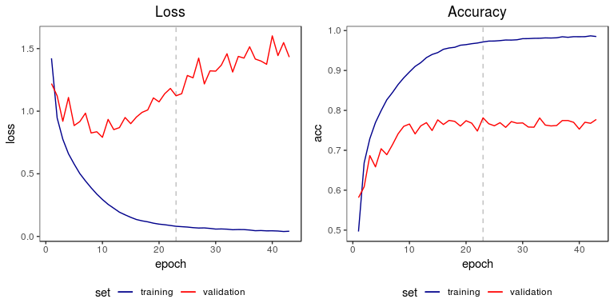

```r
history.plot(history3_bn)
```

```r
model3_bn <- load_model_hdf5('Model/model-user-he-3-bn.hdf5')
result3_bn <- evaluate.table(model3_bn)
result3_bn
```

|  | loss | acc |
| --- | --- | --- |
| train | 0.0657986 | 0.977125 |
| validation | 1.1229377 | 0.781400 |
| test | 1.1321870 | 0.782900 |

### 7. Model 3 + BN + FC (+ DO) 1

- Stack 3 Convolution Layers per block
- Add Batch Normalization step before each activation in Convolution Layers
- Add 1 Fully-Connected Layer + Dropout (0.1) Layer before the final output layer

```r
# Define
(model3_bn_fc1 <- keras_model_sequential() %>%

  layer_conv_2d(input_shape = c(img_size, img_size, 3),
                16, c(3, 3), padding = 'same',
                kernel_initializer = 'he_uniform', name = '1_conv1') %>%
  layer_batch_normalization(name = '1_bn1') %>%
  layer_activation_relu(name = '1_activation1') %>%
  layer_conv_2d(16, c(3, 3), padding = 'same',
                kernel_initializer = 'he_uniform', name = '1_conv2') %>%
  layer_batch_normalization(name = '1_bn2') %>%
  layer_activation_relu(name = '1_activation2') %>%
  layer_conv_2d(16, c(3, 3), padding = 'same',
                kernel_initializer = 'he_uniform', name = '1_conv3') %>%
  layer_batch_normalization(name = '1_bn3') %>%
  layer_activation_relu(name = '1_activation3') %>%
  layer_max_pooling_2d(c(2, 2), name = '1_pool') %>%

  layer_conv_2d(32, c(3, 3), padding = 'same',
                kernel_initializer = 'he_uniform', name = '2_conv1') %>%
  layer_batch_normalization(name = '2_bn1') %>%
  layer_activation_relu(name = '2_activation1') %>%
  layer_conv_2d(32, c(3, 3), padding = 'same',
                kernel_initializer = 'he_uniform', name = '2_conv2') %>%
  layer_batch_normalization(name = '2_bn2') %>%
  layer_activation_relu(name = '2_activation2') %>%
  layer_conv_2d(32, c(3, 3), padding = 'same',
                kernel_initializer = 'he_uniform', name = '2_conv3') %>%
  layer_batch_normalization(name = '2_bn3') %>%
  layer_activation_relu(name = '2_activation3') %>%
  layer_max_pooling_2d(c(2, 2), name = '2_pool') %>%

  layer_conv_2d(64, c(3, 3), padding = 'same',
                kernel_initializer = 'he_uniform', name = '3_conv1') %>%
  layer_batch_normalization(name = '3_bn1') %>%
  layer_activation_relu(name = '3_activation1') %>%
  layer_conv_2d(64, c(3, 3), padding = 'same',
                kernel_initializer = 'he_uniform', name = '3_conv2') %>%
  layer_batch_normalization(name = '3_bn2') %>%
  layer_activation_relu(name = '3_activation2') %>%
  layer_conv_2d(64, c(3, 3), padding = 'same',
                kernel_initializer = 'he_uniform', name = '3_conv3') %>%
  layer_batch_normalization(name = '3_bn3') %>%
  layer_activation_relu(name = '3_activation3') %>%
  layer_max_pooling_2d(c(2, 2), name = '3_pool') %>%

  layer_flatten(name = 'flatten') %>%

  layer_dense(128, activation = 'relu',
              kernel_initializer = 'he_uniform', name = '1_dense') %>%
  layer_dropout(0.1, name = '1_dropout') %>%

  layer_dense(n_class, activation = 'softmax', name = 'output'))
```

```
## Model
## ___________________________________________________________________________
## Layer (type)                     Output Shape                  Param #
## ===========================================================================
## 1_conv1 (Conv2D)                 (None, 32, 32, 16)            448
## ___________________________________________________________________________
## 1_bn1 (BatchNormalization)       (None, 32, 32, 16)            64
## ___________________________________________________________________________
## 1_activation1 (ReLU)             (None, 32, 32, 16)            0
## ___________________________________________________________________________
## 1_conv2 (Conv2D)                 (None, 32, 32, 16)            2320
## ___________________________________________________________________________
## 1_bn2 (BatchNormalization)       (None, 32, 32, 16)            64
## ___________________________________________________________________________
## 1_activation2 (ReLU)             (None, 32, 32, 16)            0
## ___________________________________________________________________________
## 1_conv3 (Conv2D)                 (None, 32, 32, 16)            2320
## ___________________________________________________________________________
## 1_bn3 (BatchNormalization)       (None, 32, 32, 16)            64
## ___________________________________________________________________________
## 1_activation3 (ReLU)             (None, 32, 32, 16)            0
## ___________________________________________________________________________
## 1_pool (MaxPooling2D)            (None, 16, 16, 16)            0
## ___________________________________________________________________________
## 2_conv1 (Conv2D)                 (None, 16, 16, 32)            4640
## ___________________________________________________________________________
## 2_bn1 (BatchNormalization)       (None, 16, 16, 32)            128
## ___________________________________________________________________________
## 2_activation1 (ReLU)             (None, 16, 16, 32)            0
## ___________________________________________________________________________
## 2_conv2 (Conv2D)                 (None, 16, 16, 32)            9248
## ___________________________________________________________________________
## 2_bn2 (BatchNormalization)       (None, 16, 16, 32)            128
## ___________________________________________________________________________
## 2_activation2 (ReLU)             (None, 16, 16, 32)            0
## ___________________________________________________________________________
## 2_conv3 (Conv2D)                 (None, 16, 16, 32)            9248
## ___________________________________________________________________________
## 2_bn3 (BatchNormalization)       (None, 16, 16, 32)            128
## ___________________________________________________________________________
```

[output cut: 21 more lines]

```
## ___________________________________________________________________________
## 3_pool (MaxPooling2D)            (None, 4, 4, 64)              0
## ___________________________________________________________________________
## flatten (Flatten)                (None, 1024)                  0
## ___________________________________________________________________________
## 1_dense (Dense)                  (None, 128)                   131200
## ___________________________________________________________________________
## 1_dropout (Dropout)              (None, 128)                   0
## ___________________________________________________________________________
## output (Dense)                   (None, 10)                    1290
## ===========================================================================
## Total params: 254,410
## Trainable params: 253,738
## Non-trainable params: 672
## ___________________________________________________________________________
```

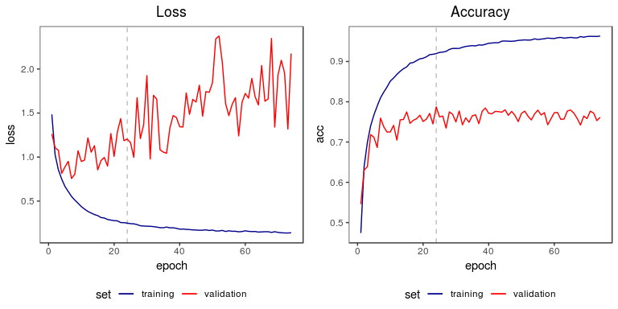

```r
# Result 1
history.plot(history3_bn_fc1)
```

```r
# Result 2
model3_bn_fc1 <- load_model_hdf5('Model/model-user-3-bn-fc-do-1.hdf5')
result3_bn_fc1 <- evaluate.table(model3_bn_fc1)
result3_bn_fc1
```

|  | loss | acc |
| --- | --- | --- |
| train | 0.1795056 | 0.94205 |
| validation | 1.2039482 | 0.78730 |
| test | 1.2325734 | 0.78300 |

### 8. Model 3 + FC (+ DO) 2

- Stack 3 Convolution Layers per block
- Add Batch Normalization step before each activation in Convolution Layers
- Add 2 Fully-Connected Layers + Dropout (0.1) Layers before the final output layer

```r
(model3_bn_fc2 <- keras_model_sequential() %>%

  layer_conv_2d(input_shape = c(img_size, img_size, 3),
                16, c(3, 3), padding = 'same',
                kernel_initializer = 'he_uniform', name = '1_conv1') %>%
  layer_batch_normalization(name = '1_bn1') %>%
  layer_activation_relu(name = '1_activation1') %>%
  layer_conv_2d(16, c(3, 3), padding = 'same',
                kernel_initializer = 'he_uniform', name = '1_conv2') %>%
  layer_batch_normalization(name = '1_bn2') %>%
  layer_activation_relu(name = '1_activation2') %>%
  layer_conv_2d(16, c(3, 3), padding = 'same',
                kernel_initializer = 'he_uniform', name = '1_conv3') %>%
  layer_batch_normalization(name = '1_bn3') %>%
  layer_activation_relu(name = '1_activation3') %>%
  layer_max_pooling_2d(c(2, 2), name = '1_pool') %>%

  layer_conv_2d(32, c(3, 3), padding = 'same',
                kernel_initializer = 'he_uniform', name = '2_conv1') %>%
  layer_batch_normalization(name = '2_bn1') %>%
  layer_activation_relu(name = '2_activation1') %>%
  layer_conv_2d(32, c(3, 3), padding = 'same',
                kernel_initializer = 'he_uniform', name = '2_conv2') %>%
  layer_batch_normalization(name = '2_bn2') %>%
  layer_activation_relu(name = '2_activation2') %>%
  layer_conv_2d(32, c(3, 3), padding = 'same',
                kernel_initializer = 'he_uniform', name = '2_conv3') %>%
  layer_batch_normalization(name = '2_bn3') %>%
  layer_activation_relu(name = '2_activation3') %>%
  layer_max_pooling_2d(c(2, 2), name = '2_pool') %>%

  layer_conv_2d(64, c(3, 3), padding = 'same',
                kernel_initializer = 'he_uniform', name = '3_conv1') %>%
  layer_batch_normalization(name = '3_bn1') %>%
  layer_activation_relu(name = '3_activation1') %>%
  layer_conv_2d(64, c(3, 3), padding = 'same',
                kernel_initializer = 'he_uniform', name = '3_conv2') %>%
  layer_batch_normalization(name = '3_bn2') %>%
  layer_activation_relu(name = '3_activation2') %>%
  layer_conv_2d(64, c(3, 3), padding = 'same',
                kernel_initializer = 'he_uniform', name = '3_conv3') %>%
  layer_batch_normalization(name = '3_bn3') %>%
  layer_activation_relu(name = '3_activation3') %>%
  layer_max_pooling_2d(c(2, 2), name = '3_pool') %>%

  layer_flatten(name = 'flatten') %>%

  layer_dense(128, activation = 'relu',
              kernel_initializer = 'he_uniform', name = '1_dense') %>%
  layer_dropout(0.1, name = '1_dropout') %>%

  layer_dense(128, activation = 'relu',
              kernel_initializer = 'he_uniform', name = '2_dense') %>%
  layer_dropout(0.1, name = '2_dropout') %>%

  layer_dense(n_class, activation = 'softmax', name = 'output'))
```

```
## Model
## ___________________________________________________________________________
## Layer (type)                     Output Shape                  Param #
## ===========================================================================
## 1_conv1 (Conv2D)                 (None, 32, 32, 16)            448
## ___________________________________________________________________________
## 1_bn1 (BatchNormalization)       (None, 32, 32, 16)            64
## ___________________________________________________________________________
## 1_activation1 (ReLU)             (None, 32, 32, 16)            0
## ___________________________________________________________________________
## 1_conv2 (Conv2D)                 (None, 32, 32, 16)            2320
## ___________________________________________________________________________
## 1_bn2 (BatchNormalization)       (None, 32, 32, 16)            64
## ___________________________________________________________________________
## 1_activation2 (ReLU)             (None, 32, 32, 16)            0
## ___________________________________________________________________________
## 1_conv3 (Conv2D)                 (None, 32, 32, 16)            2320
## ___________________________________________________________________________
## 1_bn3 (BatchNormalization)       (None, 32, 32, 16)            64
## ___________________________________________________________________________
## 1_activation3 (ReLU)             (None, 32, 32, 16)            0
## ___________________________________________________________________________
## 1_pool (MaxPooling2D)            (None, 16, 16, 16)            0
## ___________________________________________________________________________
## 2_conv1 (Conv2D)                 (None, 16, 16, 32)            4640
## ___________________________________________________________________________
## 2_bn1 (BatchNormalization)       (None, 16, 16, 32)            128
## ___________________________________________________________________________
## 2_activation1 (ReLU)             (None, 16, 16, 32)            0
## ___________________________________________________________________________
## 2_conv2 (Conv2D)                 (None, 16, 16, 32)            9248
## ___________________________________________________________________________
## 2_bn2 (BatchNormalization)       (None, 16, 16, 32)            128
## ___________________________________________________________________________
## 2_activation2 (ReLU)             (None, 16, 16, 32)            0
## ___________________________________________________________________________
## 2_conv3 (Conv2D)                 (None, 16, 16, 32)            9248
## ___________________________________________________________________________
## 2_bn3 (BatchNormalization)       (None, 16, 16, 32)            128
## ___________________________________________________________________________
```

[output cut: 25 more lines]

```
## ___________________________________________________________________________
## 1_dense (Dense)                  (None, 128)                   131200
## ___________________________________________________________________________
## 1_dropout (Dropout)              (None, 128)                   0
## ___________________________________________________________________________
## 2_dense (Dense)                  (None, 128)                   16512
## ___________________________________________________________________________
## 2_dropout (Dropout)              (None, 128)                   0
## ___________________________________________________________________________
## output (Dense)                   (None, 10)                    1290
## ===========================================================================
## Total params: 270,922
## Trainable params: 270,250
## Non-trainable params: 672
## ___________________________________________________________________________
```

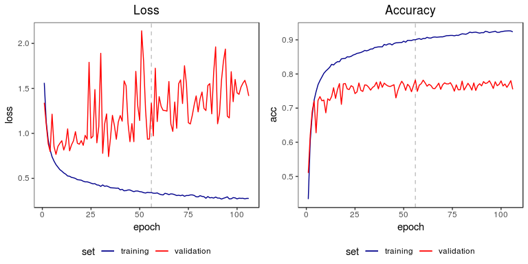

```r
# Result 1
history.plot(history3_bn_fc2)
```

```r
# Result 2
model3_bn_fc2 <- load_model_hdf5('Model/model-user-3-bn-fc-do-2.hdf5')
result3_bn_fc2 <- evaluate.table(model3_bn_fc2)
result3_bn_fc2
```

|  | loss | acc |
| --- | --- | --- |
| train | 0.2965982 | 0.9184 |
| validation | 1.3345967 | 0.7821 |
| test | 1.3401335 | 0.7811 |

## Summary

#### *Test Error* Performance of all models

```r
summ <- data.frame(
  M1_1 = 1 - result1[3, 2],
  M2_2 = 1 - result2[3, 2],
  M3_2_BN = 1 - result2_bn[3, 2],
  M4_2_BN_FC1 = 1 - result2_bn_fc1[3, 2],
  M5_2_BN_FC2 = 1 - result2_bn_fc2[3, 2],
  M6_3_BN = 1 - result3_bn[3, 2],
  M7_3_BN_FC1 = 1 - result3_bn_fc1[3, 2],
  M8_3_BN_FC2 = 1 - result3_bn_fc2[3, 2]
) %>%
  gather(MODEL, ERROR) %>%
  separate(MODEL, into = c('MODEL', 'NC', 'BN', 'FC'), sep = '_') %>%
  mutate(NC = as.numeric(NC),
         BN = ifelse(is.na(BN), 'NO', 'YES'),
         FC = ifelse(is.na(FC), 0, str_remove(FC, 'FC')))
```

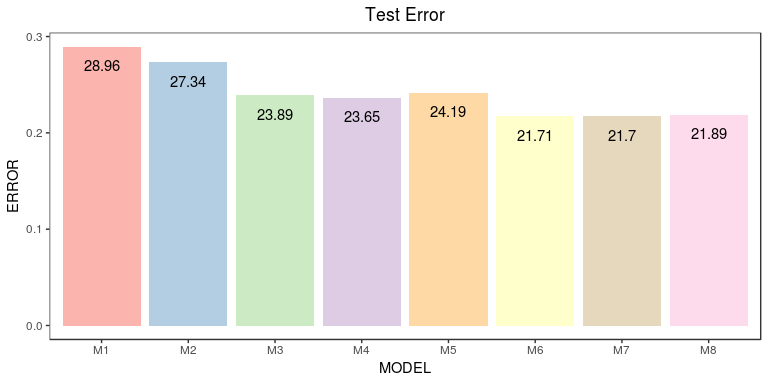

```r
summ %>%
  ggplot() + theme_test() +
  theme(plot.title = element_text(hjust = 0.5), legend.position = '') +
  scale_fill_brewer(palette = 'Pastel1') +
  geom_col(aes(MODEL, ERROR, fill = MODEL)) +
  geom_text(aes(MODEL, ERROR-0.02, label = round(ERROR, 4)*100)) +
  labs(title = 'Test Error')
```

```r
summ
```

| MODEL | NC | BN | FC | ERROR |
| --- | --- | --- | --- | --- |
| M1 | 1 | NO | 0 | 0.2896 |
| M2 | 2 | NO | 0 | 0.2734 |
| M3 | 2 | YES | 0 | 0.2389 |
| M4 | 2 | YES | 1 | 0.2365 |
| M5 | 2 | YES | 2 | 0.2419 |
| M6 | 3 | YES | 0 | 0.2171 |
| M7 | 3 | YES | 1 | 0.2170 |
| M8 | 3 | YES | 2 | 0.2189 |

- **NC**: 블록 당 연속된 합성곱 층의 수
- **BN**: 합성곱 층의 배치 정규화 여부
- **FC**: 마지막 출력 층 이전의 완전 연결 은닉층 수

**M6** 모형을 최종 모형으로 선택한다.

#### *Confusion Matrix* on Test Set using final model

```r
best <- model3_bn

pred_test <- best %>% predict_classes(Xtest, verbose = 0)
label_test <- apply(Ytest, 1, which.max) -1

table(true = label_test, pred = pred_test)
```

```
##     pred
## true   0   1   2   3   4   5   6   7   8   9
##    0 820   9  51  13  14   5   3  12  56  17
##    1  13 882   5   3   3   0   3   3  41  47
##    2  62   2 699  38  59  33  48  41  12   6
##    3  31   7  87 572  44 123  52  60  18   6
##    4  12   3  64  41 747  24  31  70   8   0
##    5  12   1  80 125  40 613  26  95   5   3
##    6  11   3  41  29  23   8 851  24  10   0
##    7  11   2  28  16  26  14   4 889   3   7
##    8  37  12   7   3   3   1   4   4 918  11
##    9  29  49   3  11   5   8   6  17  34 838
```